# Voting patterns of Immigrants

Dennis Shpits

2021-01-16

Immigration can change election results. In this R notebook we will explore the ANES dataset. We will show how immigrants can change election results by looking into their voting patterns. Particularly we will explore how foreign born voters can sway election results toward a certain party.

```r
library(haven)
library(dplyr)
library(plotrix) ##3D pie
setwd("C:/Users/Dennis/Documents/GithubClone/Spring2021-Project1-dennisshpits")
getwd()
```

```
[1] "C:/Users/Dennis/Documents/GithubClone/Spring2021-Project1-dennisshpits"
```

```r
data_sav_file <- "./data/anes_timeseries_cdf.sav"

anes_dat <- read_sav(data_sav_file)
```

In order to explore immigrant voting patterns we look at what countries our immigrants are born in. Respondents born outside the US will be important in our analysis. We also remove respondents whose parents were born in the US as they are not pure immigrants.

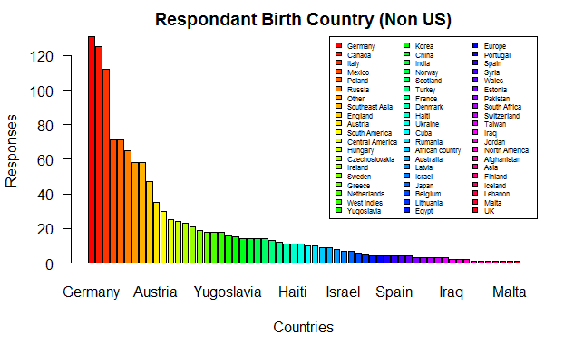

```r
##Remove NA values from Birth Country Column
Born_cleaned<-anes_dat[complete.cases(anes_dat[90]),]

##Remove people born in the US
non_us_Born_cleaned<-Born_cleaned %>% filter(VCF0142 > 199)

##Remove if both parents born in US
non_us_Born_cleaned_parents_too<-non_us_Born_cleaned %>% filter(VCF0143 != 1)

##Filter unique people out so we have one record per respondant
non_us_Born_cleaned_unique<-non_us_Born_cleaned_parents_too[!duplicated(non_us_Born_cleaned_parents_too[ , c("VCF0006a")]),]

###Create pie chart
###pie chart of respondant origin in the entire dataset
pie_chart_table<-select(non_us_Born_cleaned_unique, Country_of_Birth=VCF0142)

##Update to show country names

#convert column to string
string_column <- data.frame(lapply(pie_chart_table, as.character), stringsAsFactors=FALSE)

#update each country
string_column[string_column$Country_of_Birth == 315, "Country_of_Birth"] <- "Germany"
string_column[string_column$Country_of_Birth == 351, "Country_of_Birth"] <- "Italy"
string_column[string_column$Country_of_Birth == 209, "Country_of_Birth"] <- "Canada"
string_column[string_column$Country_of_Birth == 219, "Country_of_Birth"] <- "Mexico"
string_column[string_column$Country_of_Birth == 336, "Country_of_Birth"] <- "Poland"
string_column[string_column$Country_of_Birth == 337, "Country_of_Birth"] <- "Russia"
string_column[string_column$Country_of_Birth == 301, "Country_of_Birth"] <- "England"
string_column[string_column$Country_of_Birth == 428, "Country_of_Birth"] <- "Southeast Asia"
string_column[string_column$Country_of_Birth == 310, "Country_of_Birth"] <- "Austria"
string_column[string_column$Country_of_Birth == 259, "Country_of_Birth"] <- "South America"
string_column[string_column$Country_of_Birth == 302, "Country_of_Birth"] <- "Ireland"
string_column[string_column$Country_of_Birth == 333, "Country_of_Birth"] <- "Hungary"
string_column[string_column$Country_of_Birth == 324, "Country_of_Birth"] <- "Sweden"
string_column[string_column$Country_of_Birth == 331, "Country_of_Birth"] <- "Czechoslovakia"
string_column[string_column$Country_of_Birth == 343, "Country_of_Birth"] <- "Greece"
string_column[string_column$Country_of_Birth == 317, "Country_of_Birth"] <- "Netherlands"
string_column[string_column$Country_of_Birth == 323, "Country_of_Birth"] <- "Norway"
string_column[string_column$Country_of_Birth == 312, "Country_of_Birth"] <- "France"
string_column[string_column$Country_of_Birth == 303, "Country_of_Birth"] <- "Scotland"
string_column[string_column$Country_of_Birth == 345, "Country_of_Birth"] <- "Yugoslavia"
string_column[string_column$Country_of_Birth == 404, "Country_of_Birth"] <- "India"
string_column[string_column$Country_of_Birth == 431, "Country_of_Birth"] <- "China"
string_column[string_column$Country_of_Birth == 452, "Country_of_Birth"] <- "Korea"
string_column[string_column$Country_of_Birth == 509, "Country_of_Birth"] <- "Turkey"
string_column[string_column$Country_of_Birth == 338, "Country_of_Birth"] <- "Ukraine"
string_column[string_column$Country_of_Birth == 451, "Country_of_Birth"] <- "Japan"
string_column[string_column$Country_of_Birth == 235, "Country_of_Birth"] <- "Haiti"
string_column[string_column$Country_of_Birth == 313, "Country_of_Birth"] <- "Germany"
string_column[string_column$Country_of_Birth == 321, "Country_of_Birth"] <- "Denmark"
string_column[string_column$Country_of_Birth == 208, "Country_of_Birth"] <- "Canada"
string_column[string_column$Country_of_Birth == 233, "Country_of_Birth"] <- "Cuba"
string_column[string_column$Country_of_Birth == 344, "Country_of_Birth"] <- "Rumania"
string_column[string_column$Country_of_Birth == 207, "Country_of_Birth"] <- "Canada"
string_column[string_column$Country_of_Birth == 334, "Country_of_Birth"] <- "Latvia"
string_column[string_column$Country_of_Birth == 699, "Country_of_Birth"] <- "African country"
string_column[string_column$Country_of_Birth == 704, "Country_of_Birth"] <- "Australia"
string_column[string_column$Country_of_Birth == 239, "Country_of_Birth"] <- "West Indies"
string_column[string_column$Country_of_Birth == 311, "Country_of_Birth"] <- "Belgium"
string_column[string_column$Country_of_Birth == 504, "Country_of_Birth"] <- "Israel"
string_column[string_column$Country_of_Birth == 231, "Country_of_Birth"] <- "West Indies"
string_column[string_column$Country_of_Birth == 335, "Country_of_Birth"] <- "Lithuania"
string_column[string_column$Country_of_Birth == 353, "Country_of_Birth"] <- "Spain"
string_column[string_column$Country_of_Birth == 237, "Country_of_Birth"] <- "West Indies"
string_column[string_column$Country_of_Birth == 238, "Country_of_Birth"] <- "West Indies"
string_column[string_column$Country_of_Birth == 304, "Country_of_Birth"] <- "Wales"
string_column[string_column$Country_of_Birth == 318, "Country_of_Birth"] <- "Switzerland"
string_column[string_column$Country_of_Birth == 352, "Country_of_Birth"] <- "Portugal"
string_column[string_column$Country_of_Birth == 229, "Country_of_Birth"] <- "Central America"
string_column[string_column$Country_of_Birth == 229, "Country_of_Birth"] <- "Central America"
string_column[string_column$Country_of_Birth == 332, "Country_of_Birth"] <- "Estonia"
string_column[string_column$Country_of_Birth == 399, "Country_of_Birth"] <- "Europe"
string_column[string_column$Country_of_Birth == 406, "Country_of_Birth"] <- "Pakistan"
string_column[string_column$Country_of_Birth == 434, "Country_of_Birth"] <- "Taiwan"
string_column[string_column$Country_of_Birth == 502, "Country_of_Birth"] <- "Egypt"
string_column[string_column$Country_of_Birth == 655, "Country_of_Birth"] <- "South Africa"
string_column[string_column$Country_of_Birth == 201, "Country_of_Birth"] <- "North America"
string_column[string_column$Country_of_Birth == 314, "Country_of_Birth"] <- "Germany"
string_column[string_column$Country_of_Birth == 501, "Country_of_Birth"] <- "Egypt"
string_column[string_column$Country_of_Birth == 503, "Country_of_Birth"] <- "Iraq"
string_column[string_column$Country_of_Birth == 505, "Country_of_Birth"] <- "Jordan"
string_column[string_column$Country_of_Birth == 997, "Country_of_Birth"] <- "Other"
string_column[string_column$Country_of_Birth == 308, "Country_of_Birth"] <- "UK"
string_column[string_column$Country_of_Birth == 322, "Country_of_Birth"] <- "Finland"
string_column[string_column$Country_of_Birth == 325, "Country_of_Birth"] <- "Iceland"
string_column[string_column$Country_of_Birth == 339, "Country_of_Birth"] <- "Europe"
string_column[string_column$Country_of_Birth == 354, "Country_of_Birth"] <- "Malta"
string_column[string_column$Country_of_Birth == 401, "Country_of_Birth"] <- "Afghanistan"
string_column[string_column$Country_of_Birth == 432, "Country_of_Birth"] <- "Other"
string_column[string_column$Country_of_Birth == 499, "Country_of_Birth"] <- "Asia"
string_column[string_column$Country_of_Birth == 506, "Country_of_Birth"] <- "Lebanon"
string_column[string_column$Country_of_Birth == 232, "Country_of_Birth"] <- "Other"
string_column[string_column$Country_of_Birth == 508, "Country_of_Birth"] <- "Syria"
###########################################


x<-sort(table(string_column$Country_of_Birth), decreasing = TRUE)




##add some color and labels
#legend.text = TRUE,
barplot(x,
        col = rainbow(length(x)),
        main = "Respondant Birth Country (Non US)",
        xlab = "Countries",
        ylab = "Responses",
        las = 1,
)
legend("topright",
       legend = row.names(x),
       fill = rainbow(length(x)), ncol = 3,
       cex = 0.5)
```

The US truly is a melting pot of different cultures. We do not have an even distribution of respondents from each country, but nevertheless they share one thing in common: they were not born in the US.

```r
sprintf("We have %i unique respondents that were born outside the US", nrow(string_column))
```

```
[1] "We have 1237 unique respondents that were born outside the US"
```

Using this sample size we can get some insight into how foreign born Americans vote. We look at how respondents self Identify. We see that we have more Democrats in our respondents than Republicans.

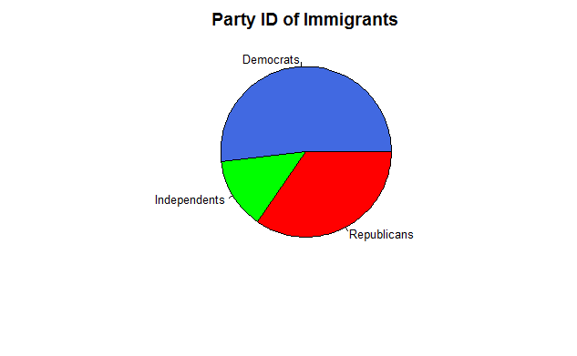

```r
###pie chart of respondent party ID
pie_chart_party<-select(non_us_Born_cleaned_unique, Party_ID=VCF0303)

pie_chart_party_cleaned<-pie_chart_party[complete.cases(pie_chart_party[1]),]

string_party_col <- data.frame(lapply(pie_chart_party_cleaned, as.character), stringsAsFactors=FALSE)

cols = c("royalblue", "green", "red")
#update each country
string_party_col[string_party_col$Party_ID == 1, "Party_ID"] <- "Democrats"
string_party_col[string_party_col$Party_ID == 2, "Party_ID"] <- "Independents"
string_party_col[string_party_col$Party_ID == 3, "Party_ID"] <- "Republicans"

# Plot the chart with title.
pie(table(string_party_col),cex = 0.8, main = "Party ID of Immigrants", col = cols)
```

```r
NA
NA
```

```r
party_birth_place<-select(non_us_Born_cleaned_unique, Party_ID=VCF0303, Country_of_Birth = VCF0142)

party_birth_place_cleaned<-party_birth_place[complete.cases(party_birth_place[1]),]
```